# IODS Exercise 6

## Summaries of the data

Now we will look at the “post-treatment” summaries for each group, ignoring the starting measure on day 1 and compering the means of the rest of the measured days until day 64.

```r
# Create a summary data by group and ID with mean as the summary variable (ignoring baseline time 1).
RATSL64S <- RATSL %>%
  filter(time > 1) %>%
  group_by(Group, ID) %>%
  summarise( mean=mean(weight) ) %>%
  ungroup()

# Glimpse the data
glimpse(RATSL64S)
```

```
## Observations: 16
## Variables: 3
## $ Group <fct> 1, 1, 1, 1, 1, 1, 1, 1, 2, 2, 2, 2, 3, 3, 3, 3
## $ ID    <fct> 1, 2, 3, 4, 5, 6, 7, 8, 9, 10, 11, 12, 13, 14, 15, 16
## $ mean  <dbl> 263.2, 238.9, 261.7, 267.2, 270.9, 276.2, 274.6, 267.5, ...
```

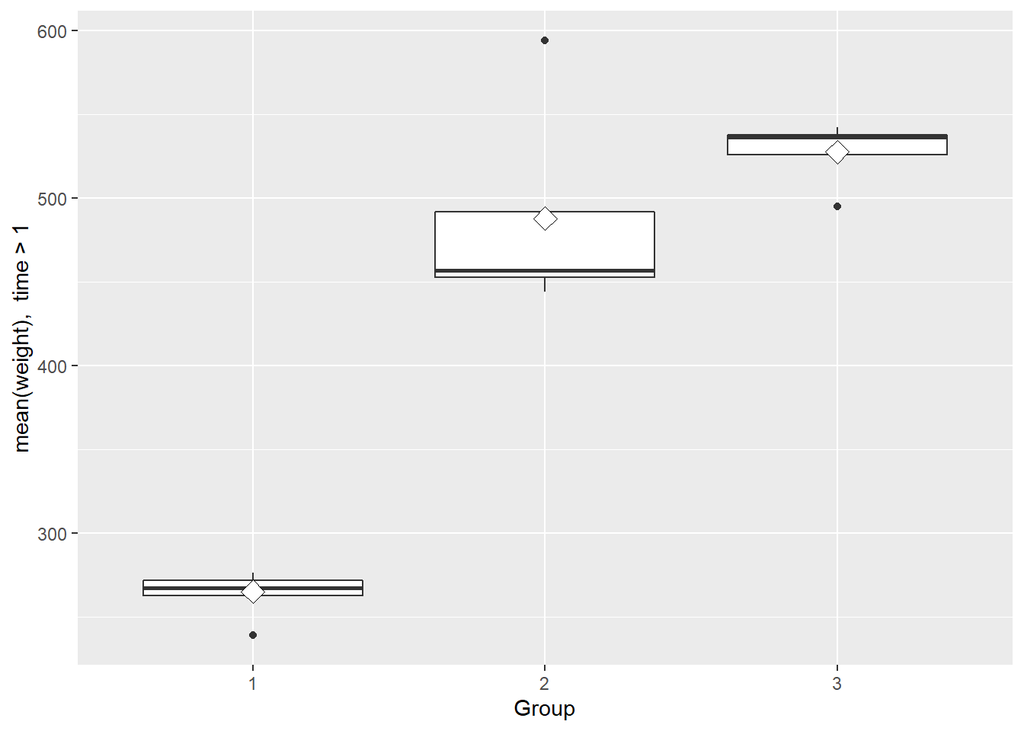

```r
# Draw a boxplot of the mean versus treatment
ggplot(RATSL64S, aes(x = Group, y = mean)) +
  geom_boxplot() +   stat_summary(fun.y = "mean", geom = "point", shape=23, size=4, fill = "white") +
  scale_y_continuous(name = "mean(weight),  time > 1")
```

In the box plot, we can see how the mean values differ between the groups. We can also see three ouliers that could possibly bias the results. We remove them and plot the boxplot again after that.

```r
# Create a new data by filtering the three outliers and adjust the ggplot code the draw the plot again with the new data

RATSL64S1 <- RATSL %>%
  filter(time > 1) %>%
  group_by(Group, ID) %>%
  summarise( mean=mean(weight) ) %>%
  ungroup() %>% filter((mean > 250 & Group == 1) | (mean < 550 & Group == 2) | (mean > 500 & Group == 3)) #This filters out the outlier means for each group

# Glimpse the data
glimpse(RATSL64S1)
```

```
## Observations: 13
## Variables: 3
## $ Group <fct> 1, 1, 1, 1, 1, 1, 1, 2, 2, 2, 3, 3, 3
## $ ID    <fct> 1, 3, 4, 5, 6, 7, 8, 9, 10, 11, 14, 15, 16
## $ mean  <dbl> 263.2, 261.7, 267.2, 270.9, 276.2, 274.6, 267.5, 443.9, ...
```

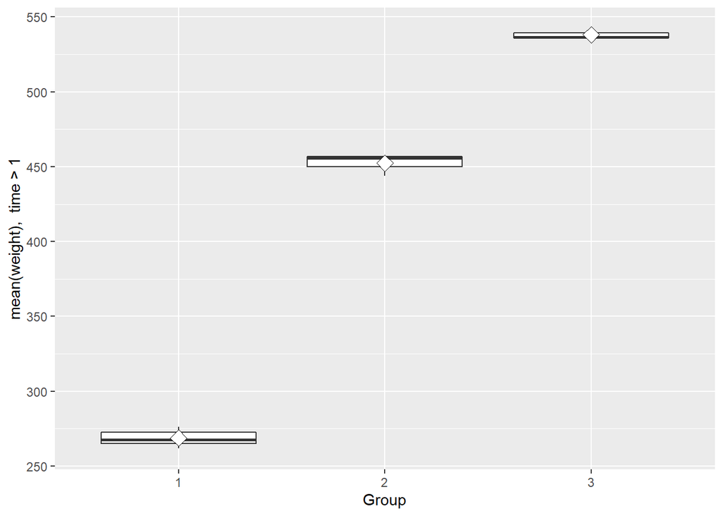

```r
# Draw a boxplot of the mean versus treatment
ggplot(RATSL64S1, aes(x = Group, y = mean)) +
  geom_boxplot() +
  stat_summary(fun.y = "mean", geom = "point", shape=23, size=4, fill = "white") +
  scale_y_continuous(name = "mean(weight),  time > 1")
```

In the above plot, the outliers are removed and the boxplots become more gathered with small variation. It is easy to visually observe that group 1 is clearly separate from group 2 and 3.

The next step of the analysis is to perform a T-test to see if the differences between groups statistical significance. A t-test can only be done with two categories. Therefore, I will drop the first group for the test and concentrate on group 2 and 3 that are more close to each other.

```r
# Perform a two-sample t-test
t.test(mean ~ Group, data = (filter(RATSL64S1, Group != 1)), var.equal = TRUE)
```

```
##
##  Two Sample t-test
##
## data:  mean by Group
## t = -18.235, df = 4, p-value = 5.32e-05
## alternative hypothesis: true difference in means is not equal to 0
## 95 percent confidence interval:
##  -98.94088 -72.79246
## sample estimates:
## mean in group 2 mean in group 3
##        452.4000        538.2667
```

I am not completely sure how to interpret the t-test, but it seems that the p-value is so low that we can reject the null hypothesis and consider the difference between group 2 and 3 to be statistically significant.

As the final step, we fit a linear model to the mean values of each treatment with both treatment and baseline value as explanatory variables.

```r
# Add the baseline from the original data as a new variable to the summary data

  # First, load the original data we had before data wrangling
          RATS <- read.table(file = "https://raw.githubusercontent.com/KimmoVehkalahti/MABS/master/Examples/data/rats.txt", sep = "\t", header = T)
      str(RATS)
```

```
## 'data.frame':    16 obs. of  13 variables:
##  $ ID   : int  1 2 3 4 5 6 7 8 9 10 ...
##  $ Group: int  1 1 1 1 1 1 1 1 2 2 ...
##  $ WD1  : int  240 225 245 260 255 260 275 245 410 405 ...
##  $ WD8  : int  250 230 250 255 260 265 275 255 415 420 ...
##  $ WD15 : int  255 230 250 255 255 270 260 260 425 430 ...
##  $ WD22 : int  260 232 255 265 270 275 270 268 428 440 ...
##  $ WD29 : int  262 240 262 265 270 275 273 270 438 448 ...
##  $ WD36 : int  258 240 265 268 273 277 274 265 443 460 ...
##  $ WD43 : int  266 243 267 270 274 278 276 265 442 458 ...
##  $ WD44 : int  266 244 267 272 273 278 271 267 446 464 ...
##  $ WD50 : int  265 238 264 274 276 284 282 273 456 475 ...
##  $ WD57 : int  272 247 268 273 278 279 281 274 468 484 ...
##  $ WD64 : int  278 245 269 275 280 281 284 278 478 496 ...
```

```r
  ## Adding the baseline
  RATSL64S2 <- RATSL64S %>%
    mutate(baseline = RATS$WD1)
  str(RATSL64S2)
```

```
## Classes 'tbl_df', 'tbl' and 'data.frame':    16 obs. of  4 variables:
##  $ Group   : Factor w/ 3 levels "1","2","3": 1 1 1 1 1 1 1 1 2 2 ...
##  $ ID      : Factor w/ 16 levels "1","2","3","4",..: 1 2 3 4 5 6 7 8 9 10 ...
##  $ mean    : num  263 239 262 267 271 ...
##  $ baseline: int  240 225 245 260 255 260 275 245 410 405 ...
```

```r
  # Fit the linear model with the mean as the response
    fit <- lm(mean ~ baseline + Group, data = RATSL64S2)

  # Compute the analysis of variance table for the fitted model with anova()
    summary(fit)
```

```
##
## Call:
## lm(formula = mean ~ baseline + Group, data = RATSL64S2)
##
## Residuals:
##     Min      1Q  Median      3Q     Max
## -23.905  -4.194   2.190   7.577  14.800
##
## Coefficients:
##             Estimate Std. Error t value Pr(>|t|)
## (Intercept) 33.16375   21.87657   1.516   0.1554
## baseline     0.92513    0.08572  10.793 1.56e-07 ***
## Group2      34.85753   18.82308   1.852   0.0888 .
## Group3      23.67526   23.25324   1.018   0.3287
## ---
## Signif. codes:  0 '***' 0.001 '**' 0.01 '*' 0.05 '.' 0.1 ' ' 1
##
## Residual standard error: 11.68 on 12 degrees of freedom
## Multiple R-squared:  0.9936, Adjusted R-squared:  0.992
## F-statistic: 622.1 on 3 and 12 DF,  p-value: 1.989e-13
```

What kind of interpretation can we make of this? The baseline is at least a statistically significant predictor of the mean value. The coefficient for group 2 is higher that for group 3, although not statistidally significant. Could this still indicate that the diet of group 2 leads to higher rates of weight increase? Unfortunately, my comprehension of the statistical theory behind this is not on a level to continue the intepretation from this point.

## Analysis on BPRS data according to MABS chapter 9.

For this part, I will use the data from the MBRS dataset. The data describes the treatment of patients suspected to have schizophrenia where bprs is an index of symptoms. The subjects are divided into two groups who recieve different treatments. The goal of the exercise is to fit a random slope and intercept model to the data and see if the model can predict the observed values.

### Read data

I load the data in long form and refactor treatment and subject.

```r
  # Read data from the data wrangling part
    BPRSL <- read.table(file = "data/bprsl.csv", header = T, sep = ";")
  # Refactor treatment and subject
    BPRSL$treatment <- factor(BPRSL$treatment)
    BPRSL$subject <- factor(BPRSL$subject)
  # Explore
    str(BPRSL)
```

```
## 'data.frame':    360 obs. of  5 variables:
##  $ treatment: Factor w/ 2 levels "1","2": 1 1 1 1 1 1 1 1 1 1 ...
##  $ subject  : Factor w/ 20 levels "1","2","3","4",..: 1 2 3 4 5 6 7 8 9 10 ...
##  $ weeks    : Factor w/ 9 levels "week0","week1",..: 1 1 1 1 1 1 1 1 1 1 ...
##  $ bprs     : int  42 58 54 55 72 48 71 30 41 57 ...
##  $ week     : int  0 0 0 0 0 0 0 0 0 0 ...
```

Now we have loaded the BPRS data in long format.

## Graphical exploration

Let’s plot the data.

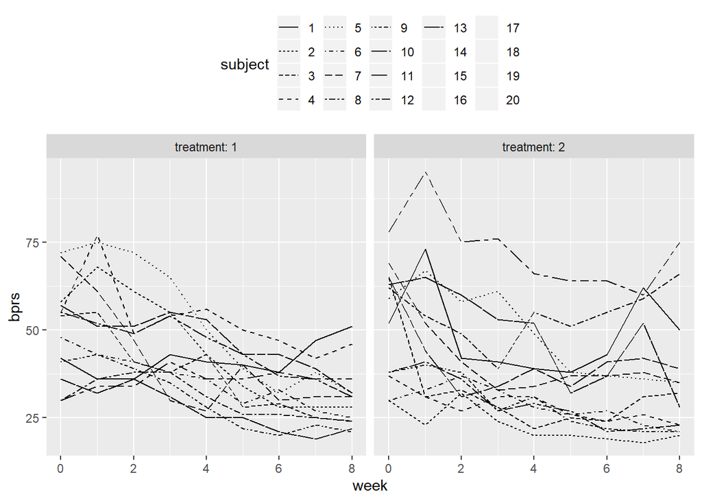

```r
# Plot the BPRSL data
ggplot(BPRSL, aes(x = week, y = bprs, linetype = subject)) +
  geom_line() +
  facet_grid(. ~ treatment, labeller = label_both) +
  theme(legend.position = "top") +
  scale_y_continuous(limits = c(min(BPRSL$bprs), max(BPRSL$bprs)))
```

### Linear regression

Next, a regression model is created where week and treatment is fitted on bprs.

```r
# create a regression model RATS_reg
BPRS_reg <- lm(bprs ~ week + treatment, data = BPRSL)

# print out a summary of the model
summary(BPRS_reg)
```

```
##
## Call:
## lm(formula = bprs ~ week + treatment, data = BPRSL)
##
## Residuals:
##     Min      1Q  Median      3Q     Max
## -22.454  -8.965  -3.196   7.002  50.244
##
## Coefficients:
##             Estimate Std. Error t value Pr(>|t|)
## (Intercept)  46.4539     1.3670  33.982   <2e-16 ***
## week         -2.2704     0.2524  -8.995   <2e-16 ***
## treatment2    0.5722     1.3034   0.439    0.661
## ---
## Signif. codes:  0 '***' 0.001 '**' 0.01 '*' 0.05 '.' 0.1 ' ' 1
##
## Residual standard error: 12.37 on 357 degrees of freedom
## Multiple R-squared:  0.1851, Adjusted R-squared:  0.1806
## F-statistic: 40.55 on 2 and 357 DF,  p-value: < 2.2e-16
```

We will try a random intercept model instead, which allows the intercept to be different for each subject.

```r
# Random intercept model
BPRS_ref <- lmer(bprs ~ week + treatment + (1 | subject), data = BPRSL, REML = FALSE)

# Print the summary of the model
summary(BPRS_ref)
```

```
## Linear mixed model fit by maximum likelihood  ['lmerMod']
## Formula: bprs ~ week + treatment + (1 | subject)
##    Data: BPRSL
##
##      AIC      BIC   logLik deviance df.resid
##   2748.7   2768.1  -1369.4   2738.7      355
##
## Scaled residuals:
##     Min      1Q  Median      3Q     Max
## -3.0481 -0.6749 -0.1361  0.4813  3.4855
##
## Random effects:
##  Groups   Name        Variance Std.Dev.
##  subject  (Intercept)  47.41    6.885
##  Residual             104.21   10.208
## Number of obs: 360, groups:  subject, 20
##
## Fixed effects:
##             Estimate Std. Error t value
## (Intercept)  46.4539     1.9090  24.334
## week         -2.2704     0.2084 -10.896
## treatment2    0.5722     1.0761   0.532
##
## Correlation of Fixed Effects:
##            (Intr) week
## week       -0.437
## treatment2 -0.282  0.000
```

The main difference in this model seems to be that the standard deviation of the residuals became much smaller.

Next we fit a model with both random intercept and random slope, allowing each subject to also have a different slope.

```r
# create a random intercept and random slope model
BPRS_ref1 <- lmer(bprs ~ week + treatment + (week | subject), data = BPRSL, REML = FALSE)

# print a summary of the model
summary(BPRS_ref1)
```

```
## Linear mixed model fit by maximum likelihood  ['lmerMod']
## Formula: bprs ~ week + treatment + (week | subject)
##    Data: BPRSL
##
##      AIC      BIC   logLik deviance df.resid
##   2745.4   2772.6  -1365.7   2731.4      353
##
## Scaled residuals:
##     Min      1Q  Median      3Q     Max
## -2.8919 -0.6194 -0.0691  0.5531  3.7977
##
## Random effects:
##  Groups   Name        Variance Std.Dev. Corr
##  subject  (Intercept) 64.8222  8.0512
##           week         0.9609  0.9803   -0.51
##  Residual             97.4304  9.8707
## Number of obs: 360, groups:  subject, 20
##
## Fixed effects:
##             Estimate Std. Error t value
## (Intercept)  46.4539     2.1052  22.066
## week         -2.2704     0.2977  -7.626
## treatment2    0.5722     1.0405   0.550
##
## Correlation of Fixed Effects:
##            (Intr) week
## week       -0.582
## treatment2 -0.247  0.000
```

We perforn an ANOVA (Analysis of variance) test on both models.

```r
# perform an ANOVA test on the two models
anova(BPRS_ref1, BPRS_ref)
```

```
## Data: BPRSL
## Models:
## BPRS_ref: bprs ~ week + treatment + (1 | subject)
## BPRS_ref1: bprs ~ week + treatment + (week | subject)
##           Df    AIC    BIC  logLik deviance  Chisq Chi Df Pr(>Chisq)
## BPRS_ref   5 2748.7 2768.1 -1369.4   2738.7
## BPRS_ref1  7 2745.4 2772.6 -1365.7   2731.4 7.2721      2    0.02636 *
## ---
## Signif. codes:  0 '***' 0.001 '**' 0.01 '*' 0.05 '.' 0.1 ' ' 1
```

Unfortunately, I don’t know how to interpret these results. Moving on to the next model taken from Data Camp.

Here we creace a random intercept and slope model which also includes interaction between week and treatment.

```r
# create a random intercept and random slope model with the interaction
BPRS_ref2 <- lmer(bprs ~ week + treatment + (week | subject) + (week * treatment), data = BPRSL, REML = FALSE)

# print a summary of the model
summary(BPRS_ref2)
```

```
## Linear mixed model fit by maximum likelihood  ['lmerMod']
## Formula: bprs ~ week + treatment + (week | subject) + (week * treatment)
##    Data: BPRSL
##
##      AIC      BIC   logLik deviance df.resid
##   2744.3   2775.4  -1364.1   2728.3      352
##
## Scaled residuals:
##     Min      1Q  Median      3Q     Max
## -3.0512 -0.6271 -0.0768  0.5288  3.9260
##
## Random effects:
##  Groups   Name        Variance Std.Dev. Corr
##  subject  (Intercept) 64.9964  8.0620
##           week         0.9687  0.9842   -0.51
##  Residual             96.4707  9.8220
## Number of obs: 360, groups:  subject, 20
##
## Fixed effects:
##                 Estimate Std. Error t value
## (Intercept)      47.8856     2.2521  21.262
## week             -2.6283     0.3589  -7.323
## treatment2       -2.2911     1.9090  -1.200
## week:treatment2   0.7158     0.4010   1.785
##
## Correlation of Fixed Effects:
##             (Intr) week   trtmn2
## week        -0.650
## treatment2  -0.424  0.469
## wek:trtmnt2  0.356 -0.559 -0.840
```

```r
# perform an ANOVA test on the two models
anova(BPRS_ref2, BPRS_ref1)
```

```
## Data: BPRSL
## Models:
## BPRS_ref1: bprs ~ week + treatment + (week | subject)
## BPRS_ref2: bprs ~ week + treatment + (week | subject) + (week * treatment)
##           Df    AIC    BIC  logLik deviance  Chisq Chi Df Pr(>Chisq)
## BPRS_ref1  7 2745.4 2772.6 -1365.7   2731.4
## BPRS_ref2  8 2744.3 2775.4 -1364.1   2728.3 3.1712      1    0.07495 .
## ---
## Signif. codes:  0 '***' 0.001 '**' 0.01 '*' 0.05 '.' 0.1 ' ' 1
```

And as previously, I am unable to provide a good interpretation. Moving on.

### Fitted versus observed values

In the last part of the analysis, I will predict fitted values from the model above and make two plots. One showing the fitted values and one showing the observed values.

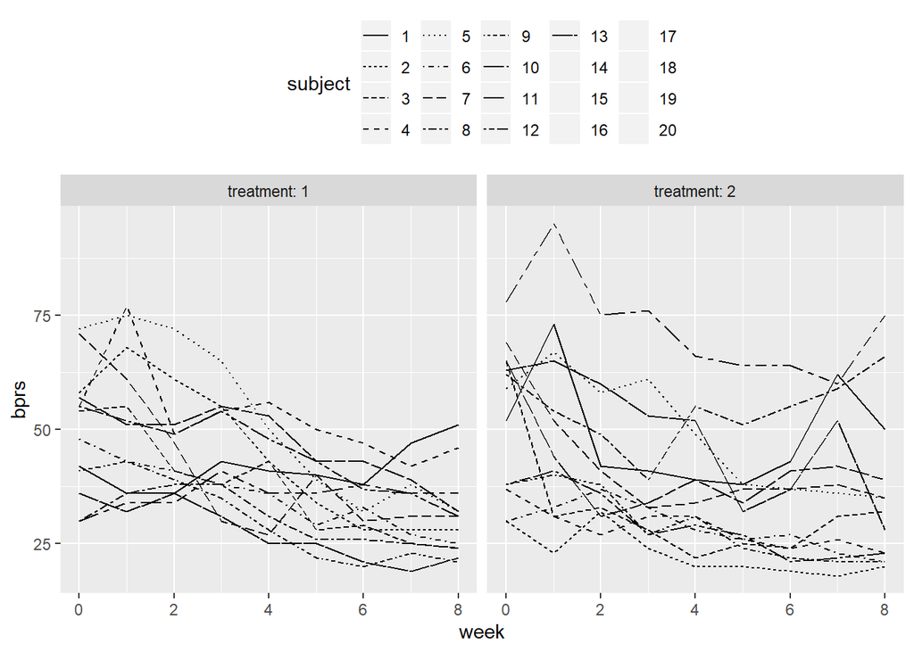

```r
# Create a vector of the fitted values
Fitted <- fitted(BPRS_ref2)

# Create a new column fitted to RATSL
BPRSL$fitted <- Fitted

# draw the plot of RATSL with the observed Weight values
ggplot(BPRSL, aes(x = week, y = bprs, linetype = subject)) +
  geom_line() +
  facet_grid(. ~ treatment, labeller = label_both) +
  theme(legend.position = "top") +
  scale_y_continuous(limits = c(min(BPRSL$bprs), max(BPRSL$bprs)))
```

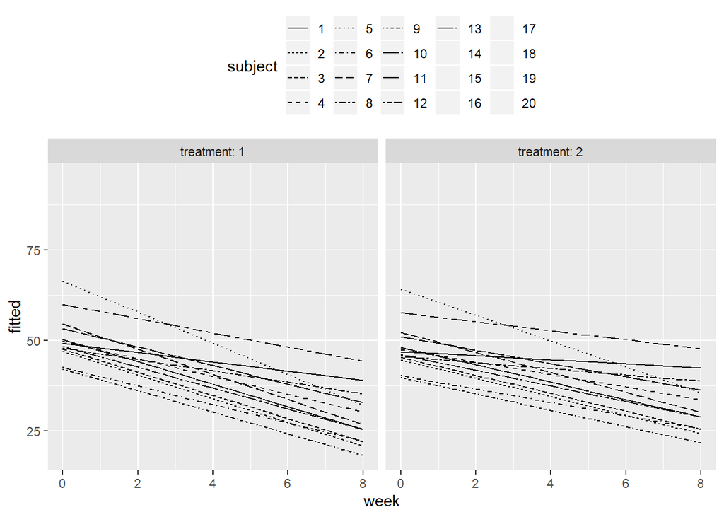

```r
# draw the plot of RATSL with the Fitted values of weight
ggplot(BPRSL, aes(x = week, y = fitted, linetype = subject)) +
  geom_line() +
  facet_grid(. ~ treatment, labeller = label_both) +
  theme(legend.position = "top") +
  scale_y_continuous(limits = c(min(BPRSL$bprs), max(BPRSL$bprs)))
```

The plot based on fitted values indeed shows lines with different intercepts and slopes for each subject.